# LAB3

Marisa Montoya, Majo Morales, Luis Garcia

8/16/2021

#Laboratorio 3 reconocimiento de caracteres en manuscritos

##Analisis Exploratorio

Los archivos de datos train.csv y test.csv contienen imágenes en escala de grises de dígitos dibujados a mano, del cero al nueve.Cada imagen tiene 28 píxeles de altura y 28 píxeles de ancho, para un total de 784 píxeles en total. Cada píxel tiene un único valor de píxel asociado, que indica la luminosidad u oscuridad de ese píxel, con números más altos que significan más oscuros. Este valor de píxel es un número entero entre 0 y 255, inclusive.El conjunto de datos de entrenamiento, (train.csv), tiene 785 columnas. La primera columna, llamada “etiqueta”, es el dígito dibujado por el usuario. El resto de las columnas contienen los valores decadapíxel dela imagen asociada.Cada columna de píxeles en el conjunto de entrenamiento tiene un nombre como pixelx, donde x es un número entero entre 0 y 783, inclusive. Para ubicar este píxel en la imagen, supongamos que hemos descompuesto x como x = i * 28 + j, donde i y j son números enteros entre 0 y 27, inclusive. Luego, pixelx se ubica en la fila iy la columna j de una matriz de 28 x 28, (indexando por cero)

```
## 'data.frame':    42000 obs. of  785 variables:
##  $ label   : int  1 0 1 4 0 0 7 3 5 3 ...
##  $ pixel0  : int  0 0 0 0 0 0 0 0 0 0 ...
##  $ pixel1  : int  0 0 0 0 0 0 0 0 0 0 ...
##  $ pixel2  : int  0 0 0 0 0 0 0 0 0 0 ...
##  $ pixel3  : int  0 0 0 0 0 0 0 0 0 0 ...
##  $ pixel4  : int  0 0 0 0 0 0 0 0 0 0 ...
##  $ pixel5  : int  0 0 0 0 0 0 0 0 0 0 ...
##  $ pixel6  : int  0 0 0 0 0 0 0 0 0 0 ...
##  $ pixel7  : int  0 0 0 0 0 0 0 0 0 0 ...
##  $ pixel8  : int  0 0 0 0 0 0 0 0 0 0 ...
##  $ pixel9  : int  0 0 0 0 0 0 0 0 0 0 ...
##  $ pixel10 : int  0 0 0 0 0 0 0 0 0 0 ...
##  $ pixel11 : int  0 0 0 0 0 0 0 0 0 0 ...
##  $ pixel12 : int  0 0 0 0 0 0 0 0 0 0 ...
```

[output cut: 771 more lines]

```
##      label           pixel0      pixel1      pixel2      pixel3      pixel4
##  Min.   :0.000   Min.   :0   Min.   :0   Min.   :0   Min.   :0   Min.   :0
##  1st Qu.:2.000   1st Qu.:0   1st Qu.:0   1st Qu.:0   1st Qu.:0   1st Qu.:0
##  Median :4.000   Median :0   Median :0   Median :0   Median :0   Median :0
##  Mean   :4.457   Mean   :0   Mean   :0   Mean   :0   Mean   :0   Mean   :0
##  3rd Qu.:7.000   3rd Qu.:0   3rd Qu.:0   3rd Qu.:0   3rd Qu.:0   3rd Qu.:0
##  Max.   :9.000   Max.   :0   Max.   :0   Max.   :0   Max.   :0   Max.   :0
##      pixel5      pixel6      pixel7      pixel8      pixel9     pixel10
##  Min.   :0   Min.   :0   Min.   :0   Min.   :0   Min.   :0   Min.   :0
##  1st Qu.:0   1st Qu.:0   1st Qu.:0   1st Qu.:0   1st Qu.:0   1st Qu.:0
##  Median :0   Median :0   Median :0   Median :0   Median :0   Median :0
##  Mean   :0   Mean   :0   Mean   :0   Mean   :0   Mean   :0   Mean   :0
##  3rd Qu.:0   3rd Qu.:0   3rd Qu.:0   3rd Qu.:0   3rd Qu.:0   3rd Qu.:0
##  Max.   :0   Max.   :0   Max.   :0   Max.   :0   Max.   :0   Max.   :0
##     pixel11     pixel12           pixel13             pixel14
##  Min.   :0   Min.   :  0.000   Min.   :  0.00000   Min.   :0.00e+00
##  1st Qu.:0   1st Qu.:  0.000   1st Qu.:  0.00000   1st Qu.:0.00e+00
##  Median :0   Median :  0.000   Median :  0.00000   Median :0.00e+00
##  Mean   :0   Mean   :  0.003   Mean   :  0.01119   Mean   :5.14e-03
##  3rd Qu.:0   3rd Qu.:  0.000   3rd Qu.:  0.00000   3rd Qu.:0.00e+00
##  Max.   :0   Max.   :116.000   Max.   :254.00000   Max.   :2.16e+02
##     pixel15            pixel16     pixel17     pixel18     pixel19     pixel20
##  Min.   :0.000000   Min.   :0   Min.   :0   Min.   :0   Min.   :0   Min.   :0
##  1st Qu.:0.000000   1st Qu.:0   1st Qu.:0   1st Qu.:0   1st Qu.:0   1st Qu.:0
##  Median :0.000000   Median :0   Median :0   Median :0   Median :0   Median :0
##  Mean   :0.000214   Mean   :0   Mean   :0   Mean   :0   Mean   :0   Mean   :0
##  3rd Qu.:0.000000   3rd Qu.:0   3rd Qu.:0   3rd Qu.:0   3rd Qu.:0   3rd Qu.:0
##  Max.   :9.000000   Max.   :0   Max.   :0   Max.   :0   Max.   :0   Max.   :0
##     pixel21     pixel22     pixel23     pixel24     pixel25     pixel26
##  Min.   :0   Min.   :0   Min.   :0   Min.   :0   Min.   :0   Min.   :0
##  1st Qu.:0   1st Qu.:0   1st Qu.:0   1st Qu.:0   1st Qu.:0   1st Qu.:0
##  Median :0   Median :0   Median :0   Median :0   Median :0   Median :0
##  Mean   :0   Mean   :0   Mean   :0   Mean   :0   Mean   :0   Mean   :0
##  3rd Qu.:0   3rd Qu.:0   3rd Qu.:0   3rd Qu.:0   3rd Qu.:0   3rd Qu.:0
##  Max.   :0   Max.   :0   Max.   :0   Max.   :0   Max.   :0   Max.   :0
##     pixel27     pixel28     pixel29     pixel30     pixel31     pixel32
##  Min.   :0   Min.   :0   Min.   :0   Min.   :0   Min.   :0   Min.   :0.00e+00
##  1st Qu.:0   1st Qu.:0   1st Qu.:0   1st Qu.:0   1st Qu.:0   1st Qu.:0.00e+00
##  Median :0   Median :0   Median :0   Median :0   Median :0   Median :0.00e+00
##  Mean   :0   Mean   :0   Mean   :0   Mean   :0   Mean   :0   Mean   :3.81e-04
```

[output cut: 1268 more lines]

```
##  Max.   :255.0000   Max.   :255.0000   Max.   :255.0000   Max.   :254.0000
##     pixel775           pixel776            pixel777            pixel778
##  Min.   :  0.0000   Min.   :  0.00000   Min.   :  0.00000   Min.   :  0.00000
##  1st Qu.:  0.0000   1st Qu.:  0.00000   1st Qu.:  0.00000   1st Qu.:  0.00000
##  Median :  0.0000   Median :  0.00000   Median :  0.00000   Median :  0.00000
##  Mean   :  0.1171   Mean   :  0.05902   Mean   :  0.02019   Mean   :  0.01724
##  3rd Qu.:  0.0000   3rd Qu.:  0.00000   3rd Qu.:  0.00000   3rd Qu.:  0.00000
##  Max.   :254.0000   Max.   :253.00000   Max.   :253.00000   Max.   :254.00000
##     pixel779           pixel780    pixel781    pixel782    pixel783
##  Min.   : 0.00000   Min.   :0   Min.   :0   Min.   :0   Min.   :0
##  1st Qu.: 0.00000   1st Qu.:0   1st Qu.:0   1st Qu.:0   1st Qu.:0
##  Median : 0.00000   Median :0   Median :0   Median :0   Median :0
##  Mean   : 0.00286   Mean   :0   Mean   :0   Mean   :0   Mean   :0
##  3rd Qu.: 0.00000   3rd Qu.:0   3rd Qu.:0   3rd Qu.:0   3rd Qu.:0
##  Max.   :62.00000   Max.   :0   Max.   :0   Max.   :0   Max.   :0
```

```
## [1] 42000   785
```

```
##  [1] 1 0 1 4 0 0 7 3 5 3 8 9 1 3 3 1 2 0 7 5
```

De lo que podemos observar es que se cuenta con 785 columnas, siendo la primera en donde esta la etiqueta de que numero es la que se esta tratando mientras que las demas corresponden a los 784 pixeles de la imagen en total. Mientras que las columnas de pixeles su minimo es 0 y maximo es de 255, la columna de label va de 0 a 9.

Dividimos el train y test del conjunto de datos y mostramos el head de train.

```
##       train[, 1] pixel0 pixel1 pixel2 pixel3 pixel4 pixel5 pixel6 pixel7 pixel8
## 2986           7      0      0      0      0      0      0      0      0      0
## 29925          6      0      0      0      0      0      0      0      0      0
## 29710          3      0      0      0      0      0      0      0      0      0
## 37529          3      0      0      0      0      0      0      0      0      0
## 2757           1      0      0      0      0      0      0      0      0      0
## 38938          4      0      0      0      0      0      0      0      0      0
```

Al imprimir una imagen nos damos cuenta que necesita que sea rotada una vez a la derecha para que pueda ser observada de mejor manera.

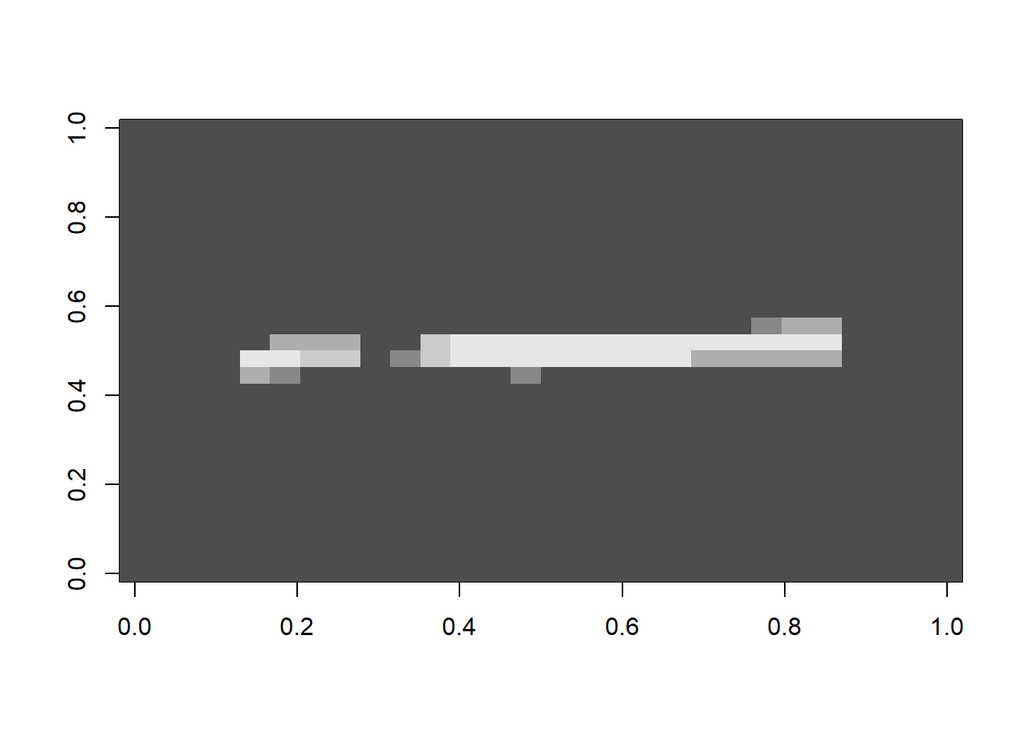

Luego imprimimos seis imagenes con sus etiquetas para poder observarlas bien.

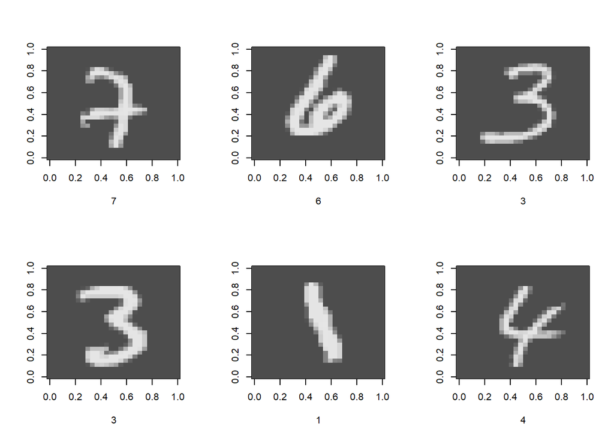

##h2o para la creacion de NN H2o es un paquete basado en una red neuronal artificial que es entrenada por un proceso estocastico usando back propagation. La red neuronal puede ser creada con varias capas escondidas. Para más conocimiento de la documentación consultar el siguiente link: https://docs.h2o.ai/h2o/latest-stable/h2o-docs/data-science/deep-learning.html

Se creo el modelo de h2o con los siguientes parametros: 1. primero se creo el localh2o para tener una mayor eficiencia de tiempo. 2. Se volvio la primera columna de train en factor para el uso del modelo 3. se creo el train set con una funcion de h2o para que pueda ser aceptado por el modelo. 4. Se instancio el modelo con parametros de a. x las columnas usadas para la prediccion (2 a 785 porque 1 es la etiqueta), seran las variables predictoras donde esta la informacion de pixels b. y es en donde se encuentra la variable dependiente, en este caso 1. c. training_frame es nuestro dataset usado para la creacion del modelo. d. activation el cual espicifica la funcion de activacion que usara el modelo (si no se especifica es rectifier) en este caso usamos Rectifier with Dropout RELu, esto porque es una manera eficiente de usar el poder de la computadora. e. input_dropout_ratio lo que nos permite mejorar la generalizacion de la NN, 0.2 ya que es el sugerido por la documentacion f. hidden_dropout_ratio ya que especifica el radio de droput en las capas escondidad de la NN, aplicando el valor default de 0.5 g. balance classes, se le da el valor de TRUE y se especifica cuantas capas escondidas se desea y de cuantos nodos seran. h. momentum_stable se coloco el valor sugerido por la documentacion 0.99 i. nesterov_accelerated_gradient para que la computadora cree el modelo de manera rapida. j. epochs, se coloco 1 ya que mide las veces que se entrena el modelo para obtener el mejor valor posible.

[output not shown]

```
## Confusion Matrix: Row labels: Actual class; Column labels: Predicted class
##           0    1   2   3    4   5    6    7   8    9  Error           Rate
## 0      1021    0   9   1    0   3   14    1   4    0 0.0304 =   32 / 1,053
## 1         0  984   8   3    3   5    2    4  15    1 0.0400 =   41 / 1,025
## 2         7    6 853  15   16   0   22   20  18    6 0.1142 =    110 / 963
## 3         3    7  25 883    1  27    7   17  22   18 0.1257 =  127 / 1,010
## 4         2    1   2   3  926   1   11    4   2   58 0.0832 =   84 / 1,010
## 5        15    3   3  28    3 908   24    6   9   18 0.1072 =  109 / 1,017
## 6         6    3   4   0    7  13  974    0   1    0 0.0337 =   34 / 1,008
## 7         1    8  10   2   13   0    3  930   0   42 0.0783 =   79 / 1,009
## 8         5   21  10  15   14  17    4    8 874    9 0.1054 =    103 / 977
## 9         4    2   2   5   26   3    1   35   9  868 0.0911 =     87 / 955
## Totals 1064 1035 926 955 1009 977 1062 1025 954 1020 0.0804 = 806 / 10,027
```

```
## Confusion Matrix: Row labels: Actual class; Column labels: Predicted class
##           0    1   2    3    4    5    6    7   8   9  Error           Rate
## 0       983    0   0    3    2    2   12    0   4   0 0.0229 =   23 / 1,006
## 1         0  986   7    7    0    4    2    3   6   0 0.0286 =   29 / 1,015
## 2         5    2 908   11   13    0   20    9   9   1 0.0716 =     70 / 978
## 3         0    1  18  929    0   28    2    8  11   8 0.0756 =   76 / 1,005
## 4         1    3   3    0  964    1   10    2   1  31 0.0512 =   52 / 1,016
## 5         1    0   3   24   11  957   14    3   2   5 0.0618 =   63 / 1,020
## 6         7    0   3    0    6   17  961    0   1   0 0.0342 =     34 / 995
## 7         4    5  13    7    5    3    6  967   1  18 0.0603 =   62 / 1,029
## 8         7    7   3   17    6   25   12    6 913  11 0.0933 =   94 / 1,007
## 9         4    1   2   13   19    2    7   19   8 916 0.0757 =     75 / 991
## Totals 1012 1005 960 1011 1026 1039 1046 1017 956 990 0.0574 = 578 / 10,062
```

```
## Confusion Matrix: Row labels: Actual class; Column labels: Predicted class
##           0    1    2   3   4    5    6    7   8   9  Error           Rate
## 0       997    0    4   1   1    4   12    0   2   0 0.0235 =   24 / 1,021
## 1         0  981    8   2   0    2    3    2   4   2 0.0229 =   23 / 1,004
## 2         3    2  954   6   3    1   29    7   5   2 0.0573 =   58 / 1,012
## 3         1    2   19 898   1   16    3   10   8   7 0.0694 =     67 / 965
## 4         0    1    4   0 946    5   15    0   1  14 0.0406 =     40 / 986
## 5         2    0    9  11   4  975   15    1   2   5 0.0479 =   49 / 1,024
## 6         5    1    1   0   3   10 1009    0   0   0 0.0194 =   20 / 1,029
## 7         1    6   12   1   4    3   11  945   1   8 0.0474 =     47 / 992
## 8         2   10    6  12   4   18   10    4 937   2 0.0677 =   68 / 1,005
## 9         2    1    2  14  17    3    6   31   5 940 0.0793 =   81 / 1,021
## Totals 1013 1004 1019 945 983 1037 1113 1000 965 980 0.0474 = 477 / 10,059
```

El error bajo nuevamente y el accuracy subio a ser de 95%, probaremos con 15 epochs.

```r
modelNN =
  h2o.deeplearning(x = 2:785,
                   y = 1,
                   training_frame = train2,
                   activation = "RectifierWithDropout",
                   input_dropout_ratio = 0.2,
                   hidden_dropout_ratios = c(0.5,0.5),
                   balance_classes = TRUE,
                   hidden = c(100,100),
                   momentum_stable = 0.99,
                   nesterov_accelerated_gradient = T,
                   epochs = 15)
h2o.confusionMatrix(modelNN)
```

```
## Confusion Matrix: Row labels: Actual class; Column labels: Predicted class
##           0   1    2   3   4   5   6    7   8   9  Error          Rate
## 0       996   0   12   2   0   1   3    1   2   0 0.0206 =  21 / 1,017
## 1         0 952   12   3   1   1   1    3   3   1 0.0256 =    25 / 977
## 2         0   2  954   2   1   2   5    6   3   0 0.0215 =    21 / 975
## 3         0   0   18 935   0  14   1    6   1   5 0.0459 =    45 / 980
## 4         0   4    6   0 941   3   7    2   1  27 0.0505 =    50 / 991
## 5         4   0   17   9   1 909   7    1   1   2 0.0442 =    42 / 951
## 6         4   1   16   0   2   0 951    0   2   0 0.0256 =    25 / 976
## 7         0   2   11   7   2   0   0  951   0   8 0.0306 =    30 / 981
## 8         7  13   10   8   1   8   5    0 919   9 0.0622 =    61 / 980
## 9         1   1   11  11  14   5   0   38   1 903 0.0832 =    82 / 985
## Totals 1012 975 1067 977 963 943 980 1008 933 955 0.0410 = 402 / 9,813
```

##Formacion de modelo con SVM

Se carga la data:

Se limpian los datos para no tener datos innecesarios:

[output not shown]

[output cut: 139 more lines]

```
## 1        0        0        0        0        0        0        0        0
##   pixel732 pixel733 pixel734 pixel735 pixel736 pixel737 pixel738 pixel739
## 1        0        0        0        0        0        0        0        0
##   pixel740 pixel741 pixel742 pixel743 pixel744 pixel745 pixel746 pixel747
## 1        0        0        0        0        0        0        0        0
##   pixel748 pixel749 pixel750 pixel751 pixel752 pixel753 pixel754 pixel755
## 1        0        0        0        0        0        0        0        0
##   pixel756 pixel757 pixel758 pixel759 pixel760 pixel761 pixel762 pixel763
## 1        0        0        0        0        0        0        0        0
##   pixel764 pixel765 pixel766 pixel767 pixel768 pixel769 pixel770 pixel771
## 1        0        0        0        0        0        0        0        0
##   pixel772 pixel773 pixel774 pixel775 pixel776 pixel777 pixel778 pixel779
## 1        0        0        0        0        0        0        0        0
##   pixel780 pixel781 pixel782 pixel783
## 1        0        0        0        0
```

[output not shown]

[output cut: 139 more lines]

```
## 42000        0        0        0        0        0        0        0        0
##       pixel731 pixel732 pixel733 pixel734 pixel735 pixel736 pixel737 pixel738
## 42000        0        0        0        0        0        0        0        0
##       pixel739 pixel740 pixel741 pixel742 pixel743 pixel744 pixel745 pixel746
## 42000        0        0        0        0        0        0        0        0
##       pixel747 pixel748 pixel749 pixel750 pixel751 pixel752 pixel753 pixel754
## 42000        0        0        0        0        0        0        0        0
##       pixel755 pixel756 pixel757 pixel758 pixel759 pixel760 pixel761 pixel762
## 42000        0        0        0        0        0        0        0        0
##       pixel763 pixel764 pixel765 pixel766 pixel767 pixel768 pixel769 pixel770
## 42000        0        0        0        0        0        0        0        0
##       pixel771 pixel772 pixel773 pixel774 pixel775 pixel776 pixel777 pixel778
## 42000        0        0        0        0        0        0        0        0
##       pixel779 pixel780 pixel781 pixel782 pixel783
## 42000        0        0        0        0        0
```

```
## [1] 0
```

```
## [1] 0
```

Al limpiar los datos se puede ver que no hay datos duplicados y tenemos titulos en ambos data sets.

```
## 'data.frame':    42000 obs. of  785 variables:
##  $ label   : int  1 0 1 4 0 0 7 3 5 3 ...
##  $ pixel0  : int  0 0 0 0 0 0 0 0 0 0 ...
##  $ pixel1  : int  0 0 0 0 0 0 0 0 0 0 ...
##  $ pixel2  : int  0 0 0 0 0 0 0 0 0 0 ...
##  $ pixel3  : int  0 0 0 0 0 0 0 0 0 0 ...
##  $ pixel4  : int  0 0 0 0 0 0 0 0 0 0 ...
##  $ pixel5  : int  0 0 0 0 0 0 0 0 0 0 ...
##  $ pixel6  : int  0 0 0 0 0 0 0 0 0 0 ...
##  $ pixel7  : int  0 0 0 0 0 0 0 0 0 0 ...
##  $ pixel8  : int  0 0 0 0 0 0 0 0 0 0 ...
##  $ pixel9  : int  0 0 0 0 0 0 0 0 0 0 ...
##  $ pixel10 : int  0 0 0 0 0 0 0 0 0 0 ...
##  $ pixel11 : int  0 0 0 0 0 0 0 0 0 0 ...
##  $ pixel12 : int  0 0 0 0 0 0 0 0 0 0 ...
```

[output cut: 86 more lines]

```
##      pixel0      pixel1      pixel2      pixel3      pixel4      pixel5
##  Min.   :0   Min.   :0   Min.   :0   Min.   :0   Min.   :0   Min.   :0
##  1st Qu.:0   1st Qu.:0   1st Qu.:0   1st Qu.:0   1st Qu.:0   1st Qu.:0
##  Median :0   Median :0   Median :0   Median :0   Median :0   Median :0
##  Mean   :0   Mean   :0   Mean   :0   Mean   :0   Mean   :0   Mean   :0
##  3rd Qu.:0   3rd Qu.:0   3rd Qu.:0   3rd Qu.:0   3rd Qu.:0   3rd Qu.:0
##  Max.   :0   Max.   :0   Max.   :0   Max.   :0   Max.   :0   Max.   :0
##      pixel6      pixel7      pixel8      pixel9     pixel10     pixel11
##  Min.   :0   Min.   :0   Min.   :0   Min.   :0   Min.   :0   Min.   :0
##  1st Qu.:0   1st Qu.:0   1st Qu.:0   1st Qu.:0   1st Qu.:0   1st Qu.:0
##  Median :0   Median :0   Median :0   Median :0   Median :0   Median :0
##  Mean   :0   Mean   :0   Mean   :0   Mean   :0   Mean   :0   Mean   :0
##  3rd Qu.:0   3rd Qu.:0   3rd Qu.:0   3rd Qu.:0   3rd Qu.:0   3rd Qu.:0
##  Max.   :0   Max.   :0   Max.   :0   Max.   :0   Max.   :0   Max.   :0
##     pixel12           pixel13             pixel14            pixel15
##  Min.   :  0.000   Min.   :  0.00000   Min.   :0.00e+00   Min.   :0.000000
##  1st Qu.:  0.000   1st Qu.:  0.00000   1st Qu.:0.00e+00   1st Qu.:0.000000
##  Median :  0.000   Median :  0.00000   Median :0.00e+00   Median :0.000000
##  Mean   :  0.003   Mean   :  0.01119   Mean   :5.14e-03   Mean   :0.000214
##  3rd Qu.:  0.000   3rd Qu.:  0.00000   3rd Qu.:0.00e+00   3rd Qu.:0.000000
##  Max.   :116.000   Max.   :254.00000   Max.   :2.16e+02   Max.   :9.000000
##     pixel16     pixel17     pixel18     pixel19     pixel20     pixel21
##  Min.   :0   Min.   :0   Min.   :0   Min.   :0   Min.   :0   Min.   :0
##  1st Qu.:0   1st Qu.:0   1st Qu.:0   1st Qu.:0   1st Qu.:0   1st Qu.:0
##  Median :0   Median :0   Median :0   Median :0   Median :0   Median :0
##  Mean   :0   Mean   :0   Mean   :0   Mean   :0   Mean   :0   Mean   :0
##  3rd Qu.:0   3rd Qu.:0   3rd Qu.:0   3rd Qu.:0   3rd Qu.:0   3rd Qu.:0
##  Max.   :0   Max.   :0   Max.   :0   Max.   :0   Max.   :0   Max.   :0
##     pixel22     pixel23     pixel24     pixel25     pixel26     pixel27
##  Min.   :0   Min.   :0   Min.   :0   Min.   :0   Min.   :0   Min.   :0
##  1st Qu.:0   1st Qu.:0   1st Qu.:0   1st Qu.:0   1st Qu.:0   1st Qu.:0
##  Median :0   Median :0   Median :0   Median :0   Median :0   Median :0
##  Mean   :0   Mean   :0   Mean   :0   Mean   :0   Mean   :0   Mean   :0
##  3rd Qu.:0   3rd Qu.:0   3rd Qu.:0   3rd Qu.:0   3rd Qu.:0   3rd Qu.:0
##  Max.   :0   Max.   :0   Max.   :0   Max.   :0   Max.   :0   Max.   :0
##     pixel28     pixel29     pixel30     pixel31     pixel32
##  Min.   :0   Min.   :0   Min.   :0   Min.   :0   Min.   :0.00e+00
##  1st Qu.:0   1st Qu.:0   1st Qu.:0   1st Qu.:0   1st Qu.:0.00e+00
##  Median :0   Median :0   Median :0   Median :0   Median :0.00e+00
##  Mean   :0   Mean   :0   Mean   :0   Mean   :0   Mean   :3.81e-04
```

[output cut: 99 more lines]

```
##  Max.   :139.0000   Max.   :255.00000   Max.   :255.0000   Max.   :255.0000
##     pixel92           pixel93           pixel94           pixel95
##  Min.   :  0.000   Min.   :  0.000   Min.   :  0.000   Min.   :  0.000
##  1st Qu.:  0.000   1st Qu.:  0.000   1st Qu.:  0.000   1st Qu.:  0.000
##  Median :  0.000   Median :  0.000   Median :  0.000   Median :  0.000
##  Mean   :  1.193   Mean   :  2.293   Mean   :  3.768   Mean   :  5.714
##  3rd Qu.:  0.000   3rd Qu.:  0.000   3rd Qu.:  0.000   3rd Qu.:  0.000
##  Max.   :255.000   Max.   :255.000   Max.   :255.000   Max.   :255.000
##     pixel96           pixel97          pixel98
##  Min.   :  0.000   Min.   :  0.00   Min.   :  0.00
##  1st Qu.:  0.000   1st Qu.:  0.00   1st Qu.:  0.00
##  Median :  0.000   Median :  0.00   Median :  0.00
##  Mean   :  7.751   Mean   : 10.05   Mean   : 12.07
##  3rd Qu.:  0.000   3rd Qu.:  0.00   3rd Qu.:  0.00
##  Max.   :255.000   Max.   :255.00   Max.   :255.00
```

Se generan subsets del conjunto de datos para que sean manejables y poder tener el dataset train y test.

```
##    0    1    2    3    4    5    6    7    8    9
## 4132 4684 4177 4351 4072 3795 4137 4401 4063 4188
```

```
## [1] 42000   785
```

```
## [1] 255
```

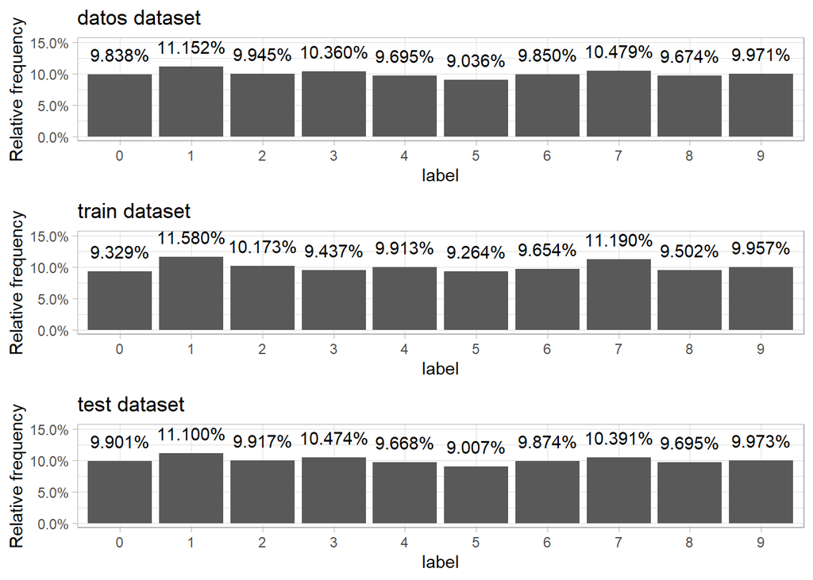

Se observa una frecuencia constante en la distribucion de los digitos en los datasets.

```
## Support Vector Machine object of class "ksvm"
##
## SV type: C-svc  (classification)
##  parameter : cost C = 1
##
## Linear (vanilla) kernel function.
##
## Number of Support Vectors : 1600
##
## Objective Function Value : -0.2664 -1.4363 -1.1685 -0.5136 -2.6863 -1.9452 -0.7796 -1.599 -0.7733 -2.157 -1.6673 -0.8293 -1.4058 -0.899 -3.1055 -4.9994 -0.9575 -4.8466 -2.0182 -3.4185 -3.9497 -2.2682 -3.6383 -1.6391 -0.9125 -11.8905 -1.2251 -2.5793 -7.2691 -3.0863 -2.1523 -1.5742 -2.7797 -1.4413 …
## Training error : 0
```

```
## Confusion Matrix and Statistics
##
##           Reference
## Prediction    0    1    2    3    4    5    6    7    8    9
##          0 3597    2   30   20    6   36   42    4   26   20
##          1    0 4065   37   25   14   25   12   26  101   20
##          2   10    9 3351  109   32   39   51   44   98   23
##          3    6   17   56 3439    2  174    2   23  138   40
##          4    6    9   65   12 3351   38   31   63   22  167
##          5   31   12   15  157    9 2866   28    9  126   21
##          6   41    4   36   26   26   66 3519    3   36    2
##          7    1    8   57   35   27   17    0 3565   39  177
##          8    6   23   46   64    8   77    6   11 3002   26
##          9    3    0   14   28  139   29    0  136   36 3232
##
## Overall Statistics
##
##                Accuracy : 0.9092
##                  95% CI : (0.9063, 0.9121)
##     No Information Rate : 0.111
##     P-Value [Acc > NIR] : < 2.2e-16
##
##                   Kappa : 0.8991
##
##  Mcnemar's Test P-Value : < 2.2e-16
##
## Statistics by Class:
##
##                      Class: 0 Class: 1 Class: 2 Class: 3 Class: 4 Class: 5
## Sensitivity           0.97190   0.9798  0.90397   0.8784  0.92723  0.85120
## Specificity           0.99448   0.9922  0.98768   0.9863  0.98777  0.98800
## Pos Pred Value        0.95083   0.9399  0.88980   0.8825  0.89028  0.87538
## Neg Pred Value        0.99690   0.9975  0.98941   0.9858  0.99218  0.98531
## Prevalence            0.09901   0.1110  0.09917   0.1047  0.09668  0.09007
## Detection Rate        0.09623   0.1087  0.08965   0.0920  0.08965  0.07667
## Detection Prevalence  0.10120   0.1157  0.10075   0.1043  0.10070  0.08759
## Balanced Accuracy     0.98319   0.9860  0.94582   0.9324  0.95750  0.91960
##                      Class: 6 Class: 7 Class: 8 Class: 9
## Sensitivity           0.95340  0.91787  0.82837  0.86695
## Specificity           0.99288  0.98922  0.99209  0.98856
## Pos Pred Value        0.93615  0.90805  0.91832  0.89356
## Neg Pred Value        0.99488  0.99046  0.98177  0.98531
## Prevalence            0.09874  0.10391  0.09695  0.09973
## Detection Rate        0.09414  0.09537  0.08031  0.08646
## Detection Prevalence  0.10056  0.10503  0.08745  0.09676
## Balanced Accuracy     0.97314  0.95355  0.91023  0.92776
```

```
## Support Vector Machine object of class "ksvm"
##
## SV type: C-svc  (classification)
##  parameter : cost C = 10
##
## Linear (vanilla) kernel function.
##
## Number of Support Vectors : 1598
##
## Objective Function Value : -0.2664 -1.4363 -1.1685 -0.5136 -2.6863 -1.9452 -0.7796 -1.599 -0.7733 -2.157 -1.6673 -0.8293 -1.4058 -0.899 -3.1055 -4.9994 -0.9575 -4.8466 -2.0182 -3.4185 -3.9497 -2.2682 -3.6383 -1.6391 -0.9125 -11.8905 -1.2251 -2.5793 -7.2691 -3.0863 -2.1523 -1.5742 -2.7797 -1.4413 …
## Training error : 0
```

```
## Confusion Matrix and Statistics
##
##           Reference
## Prediction    0    1    2    3    4    5    6    7    8    9
##          0 3597    2   30   20    6   36   42    4   26   20
##          1    0 4065   37   25   14   25   12   26  101   21
##          2   10    9 3351  109   32   39   51   44   98   23
##          3    6   17   56 3439    2  174    2   23  138   41
##          4    6    9   65   12 3351   38   31   64   22  170
##          5   31   12   15  157    9 2866   28    9  126   21
##          6   41    4   36   26   26   66 3519    3   36    2
##          7    1    8   57   35   28   16    0 3563   39  179
##          8    6   23   46   64    8   77    6   11 3002   26
##          9    3    0   14   28  138   30    0  137   36 3225
##
## Overall Statistics
##
##                Accuracy : 0.909
##                  95% CI : (0.906, 0.9119)
##     No Information Rate : 0.111
##     P-Value [Acc > NIR] : < 2.2e-16
##
##                   Kappa : 0.8988
##
##  Mcnemar's Test P-Value : < 2.2e-16
##
## Statistics by Class:
##
##                      Class: 0 Class: 1 Class: 2 Class: 3 Class: 4 Class: 5
## Sensitivity           0.97190   0.9798  0.90397   0.8784  0.92723  0.85120
## Specificity           0.99448   0.9921  0.98768   0.9863  0.98765  0.98800
## Pos Pred Value        0.95083   0.9397  0.88980   0.8822  0.88933  0.87538
## Neg Pred Value        0.99690   0.9975  0.98941   0.9858  0.99218  0.98531
## Prevalence            0.09901   0.1110  0.09917   0.1047  0.09668  0.09007
## Detection Rate        0.09623   0.1087  0.08965   0.0920  0.08965  0.07667
## Detection Prevalence  0.10120   0.1157  0.10075   0.1043  0.10080  0.08759
## Balanced Accuracy     0.98319   0.9860  0.94582   0.9324  0.95744  0.91960
##                      Class: 6 Class: 7 Class: 8 Class: 9
## Sensitivity           0.95340  0.91735  0.82837  0.86508
## Specificity           0.99288  0.98916  0.99209  0.98853
## Pos Pred Value        0.93615  0.90754  0.91832  0.89310
## Neg Pred Value        0.99488  0.99040  0.98177  0.98510
## Prevalence            0.09874  0.10391  0.09695  0.09973
## Detection Rate        0.09414  0.09532  0.08031  0.08628
## Detection Prevalence  0.10056  0.10503  0.08745  0.09660
## Balanced Accuracy     0.97314  0.95326  0.91023  0.92680
```

[output not shown]

```
## Support Vector Machines with Linear Kernel
##
## 4620 samples
##  784 predictor
##   10 classes: '0', '1', '2', '3', '4', '5', '6', '7', '8', '9'
##
## No pre-processing
## Resampling: Cross-Validated (5 fold)
## Summary of sample sizes: 3697, 3696, 3694, 3695, 3698
## Resampling results across tuning parameters:
##
##   C      Accuracy   Kappa
##   1e-03  0.8733742  0.8591797
##   1e-01  0.9199139  0.9109511
##   1e+00  0.9067128  0.8962718
##   1e+01  0.9067128  0.8962718
##   1e+02  0.9067128  0.8962718
##
## Accuracy was used to select the optimal model using the largest value.
## The final value used for the model was C = 0.1.
```

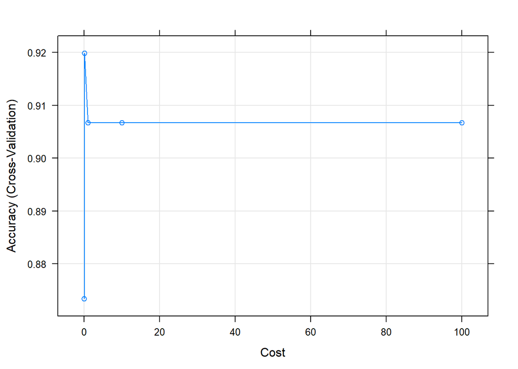

Support Vector Machines es un algoritmo de deep learning que es efectivo en espacios de altas dimensiones. Los subsets generados durante el proceso son los vectores de soporte que hacen que el uso de memoria sea mas efectivo. La eficacia del algoritmo segun la matriz de confusion fue de un 90.92% En el codigo se utlizaron bloques de: https://github.com/Srungeer-Simha/MNIST-digit-recognition-using-SVM/blob/master/MNIST%20digit%20recognition%20-%20SVM.R

##Prediccion con manuscritos de los participantes del grupo

Para esto primero se debera de cargar las imagenes a R, se uso el paquete EBImage, instalado con BiocManager. Aqui se puede encontrar la documentacion http://www.bioconductor.org/packages/release/bioc/vignettes/EBImage/inst/doc/EBImage-introduction.html#3_Image_data_representation , se muestra la imagen cargada, se cambia a una escala de grises, se convierte en un array y luego se convierte en un vector de 784 datos que corresponde a los pixeles.

Se hace un dataframe completo con todos los manuscritos a usar y se aplica el modelo de prediccion, asimismo se mostraran cada imagen hecha por los integrantes del grupo.

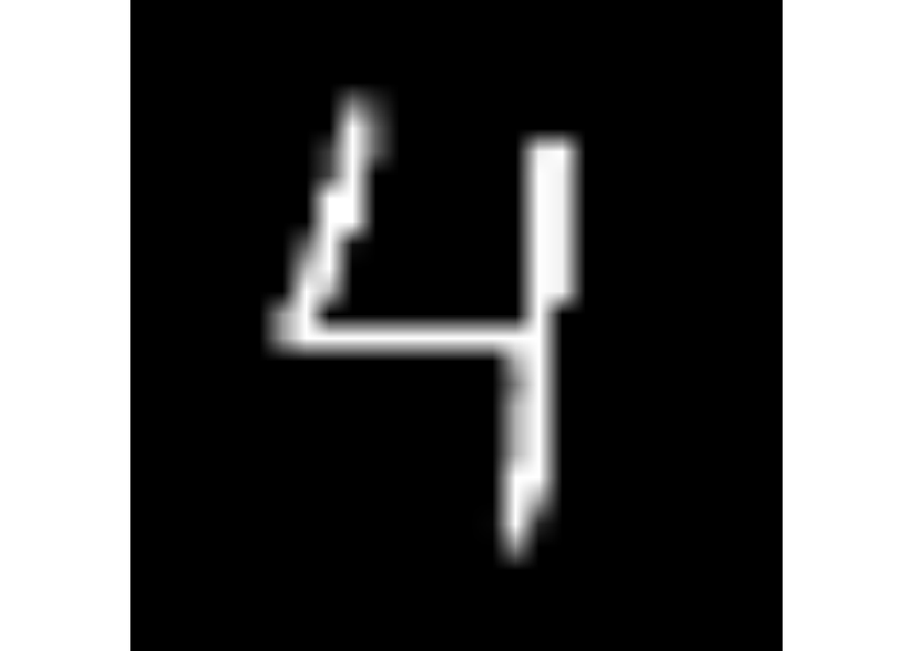

```
## Formal class 'Image' [package "EBImage"] with 2 slots
##   ..@ .Data    : num [1:28, 1:28, 1:4] 0 0 0 0 0 0 0 0 0 0 ...
##   ..@ colormode: int 2
```

```
## Image
##   colorMode    : Grayscale
##   storage.mode : double
##   dim          : 28 28
##   frames.total : 1
##   frames.render: 1
##
## imageData(object)[1:5,1:6]
##      [,1] [,2] [,3] [,4] [,5] [,6]
## [1,]    0    0    0    0    0    0
## [2,]    0    0    0    0    0    0
## [3,]    0    0    0    0    0    0
## [4,]    0    0    0    0    0    0
## [5,]    0    0    0    0    0    0
```

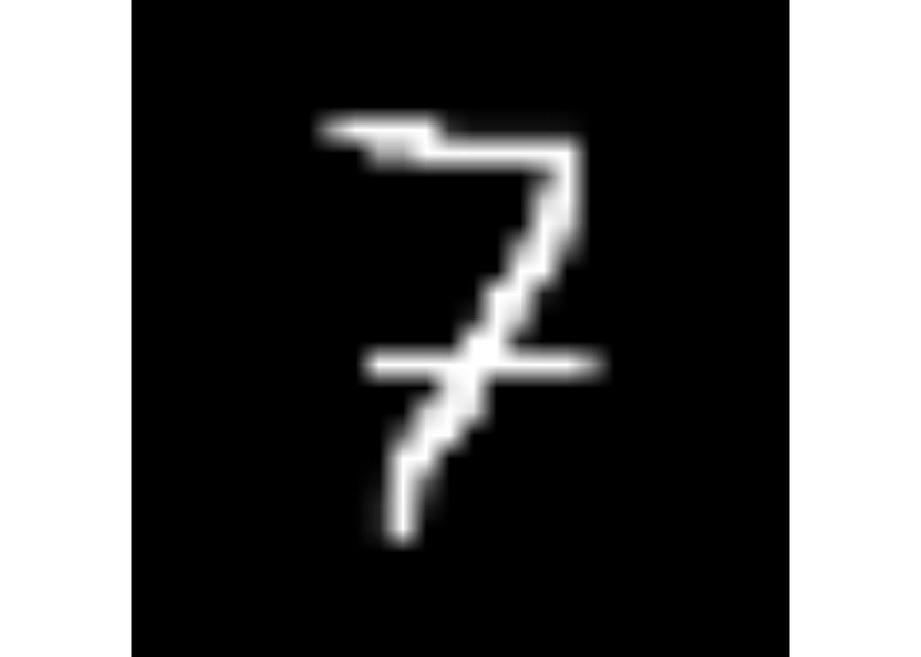

```
## Formal class 'Image' [package "EBImage"] with 2 slots
##   ..@ .Data    : num [1:28, 1:28, 1:4] 0 0 0 0 0 0 0 0 0 0 ...
##   ..@ colormode: int 2
```

```
## Image
##   colorMode    : Grayscale
##   storage.mode : double
##   dim          : 28 28
##   frames.total : 1
##   frames.render: 1
##
## imageData(object)[1:5,1:6]
##      [,1] [,2] [,3] [,4] [,5] [,6]
## [1,]    0    0    0    0    0    0
## [2,]    0    0    0    0    0    0
## [3,]    0    0    0    0    0    0
## [4,]    0    0    0    0    0    0
## [5,]    0    0    0    0    0    0
```

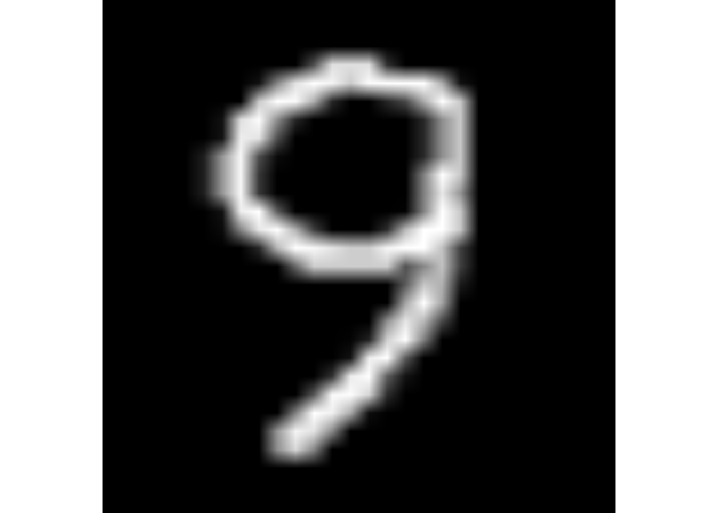

```
## Formal class 'Image' [package "EBImage"] with 2 slots
##   ..@ .Data    : num [1:28, 1:28, 1:4] 0 0 0 0 0 0 0 0 0 0 ...
##   ..@ colormode: int 2
```

```
## Image
##   colorMode    : Grayscale
##   storage.mode : double
##   dim          : 28 28
##   frames.total : 1
##   frames.render: 1
##
## imageData(object)[1:5,1:6]
##      [,1] [,2] [,3] [,4] [,5] [,6]
## [1,]    0    0    0    0    0    0
## [2,]    0    0    0    0    0    0
## [3,]    0    0    0    0    0    0
## [4,]    0    0    0    0    0    0
## [5,]    0    0    0    0    0    0
```

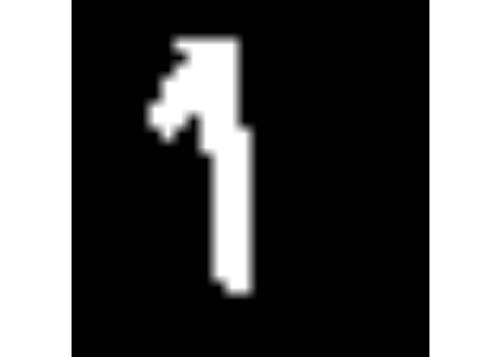

```
## Formal class 'Image' [package "EBImage"] with 2 slots
##   ..@ .Data    : num [1:28, 1:28, 1:3] 0 0 0 0 0 0 0 0 0 0 ...
##   ..@ colormode: int 2
```

```
## Image
##   colorMode    : Grayscale
##   storage.mode : double
##   dim          : 28 28
##   frames.total : 1
##   frames.render: 1
##
## imageData(object)[1:5,1:6]
##      [,1] [,2] [,3] [,4] [,5] [,6]
## [1,]    0    0    0    0    0    0
## [2,]    0    0    0    0    0    0
## [3,]    0    0    0    0    0    0
## [4,]    0    0    0    0    0    0
## [5,]    0    0    0    0    0    0
```

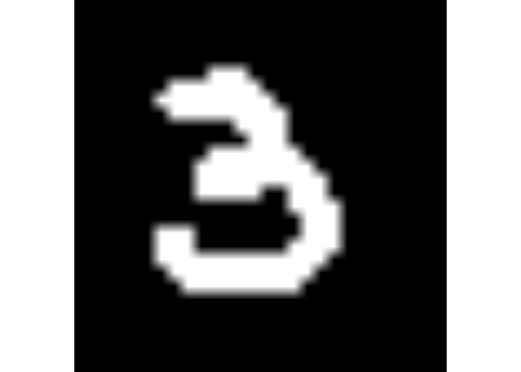

```
## Image
##   colorMode    : Grayscale
##   storage.mode : double
##   dim          : 28 28
##   frames.total : 1
##   frames.render: 1
##
## imageData(object)[1:5,1:6]
##      [,1] [,2] [,3] [,4] [,5] [,6]
## [1,]    0    0    0    0    0    0
## [2,]    0    0    0    0    0    0
## [3,]    0    0    0    0    0    0
## [4,]    0    0    0    0    0    0
## [5,]    0    0    0    0    0    0
```

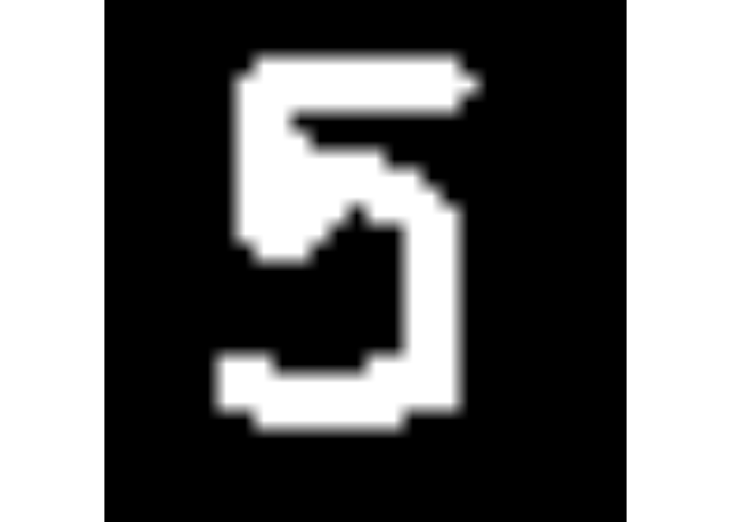

```
## Image
##   colorMode    : Grayscale
##   storage.mode : double
##   dim          : 28 28
##   frames.total : 1
##   frames.render: 1
##
## imageData(object)[1:5,1:6]
##      [,1] [,2] [,3] [,4] [,5] [,6]
## [1,]    0    0    0    0    0    0
## [2,]    0    0    0    0    0    0
## [3,]    0    0    0    0    0    0
## [4,]    0    0    0    0    0    0
## [5,]    0    0    0    0    0    0
```

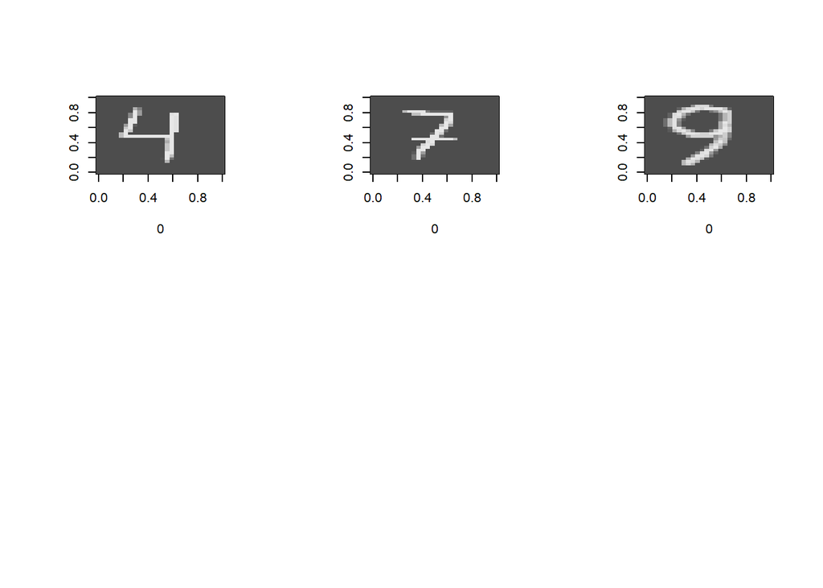

Se procede a activar el environment para h2o y a hacer la prediccion. En la prediccion se tendra como resultado un df con image id que se denomida por 1,2..6 y el valor predicho por el modelo en este test.

```
##
  |
  |                                                                      |   0%
  |
  |======================================================================| 100%
```

```
##   ImageId Label
## 1       1     4
## 2       2     7
## 3       3     3
## 4       4     2
## 5       5     3
## 6       6     2
```

Referencia de codigo realizar el modelo http://didericksen.github.io/deeplearning-r-h2o/